# Stablecoins — compare USDC, USDT and DAI transfer sizes and volumes

We want to compare three major Ethereum stablecoins:

- USDC (smart contract address: 0xa0b86991c6218b36c1d19d4a2e9eb0ce3606eb48)
- USDT (smart contract address: 0xdac17f958d2ee523a2206206994597c13d831ec7)
- DAI (smart contract address: 0x6b175474e89094c44da98b954eedeac495271d0f)

We will investigate two questions:

1. How do their transfer sizes differ?
2. How much transfer volume does each stablecoin generate?

Our workflow is:

```
Ethereum
   ↓
Etherscan
   ↓
ERC-20 transfer events
   ↓
R / tidyverse
   ↓
transfer sizes + transfer volumes
```

We use Etherscan to retrieve the already indexed ERC-20 transfer events. Etherscan’s `tokentx` endpoint can be filtered directly by token contract, so we do not need to download unrelated ERC-20 transfers first.

We use the term transfer rather than transaction throughout the lab: one Ethereum transaction can generate several ERC-20 transfer events.

## Libraries

```r
library(tidyverse)
library(httr2)
```

## Retrieve the transfers from Etherscan

The API key is not written in the code, so it does not end up on GitHub. It is read from the environment variable `ETHERSCAN_API_KEY` (set it once in the `.Renviron` file and restart R).

```r
api_key <- Sys.getenv("ETHERSCAN_API_KEY")

contracts <- c("0xa0b86991c6218b36c1d19d4a2e9eb0ce3606eb48",  # USDC
               "0xdac17f958d2ee523a2206206994597c13d831ec7",  # USDT
               "0x6b175474e89094c44da98b954eedeac495271d0f")  # DAI

read_transfers <- function(contract) {
  url <- paste0("https://api.etherscan.io/v2/api?chainid=1&module=account&action=tokentx",
                "&contractaddress=", contract,
                "&page=1&offset=10000&sort=desc&apikey=", api_key)
  response <- request(url) |> req_perform() |> resp_body_json()
  bind_rows(response$result)
}

# one call per token, then stack the three tables
transfers_raw <- map(contracts, read_transfers) |>
  bind_rows()

# amount in tokens (≈ USD) and time in seconds
transfers <- transfers_raw |>
  transmute(token = tokenSymbol,
            hash, from, to,
            amount = as.numeric(value) / 10^as.numeric(tokenDecimal),
            time = as.numeric(timeStamp))

# transfers and distinct transactions per token
transfers |>
  group_by(token) |>
  summarise(transfers = n(),
            transactions = n_distinct(hash),
            missing = sum(is.na(amount) | is.na(time)))
```

```
## # A tibble: 3 × 4
##   token transfers transactions missing
##   <chr>     <int>        <int>   <int>
## 1 DAI        1000          521       0
## 2 USDC       1000          600       0
## 3 USDT       1000          771       0
```

Some transfers have amount 0 (often spam or test transfers). We count them and leave them out of the size analysis.

```r
transfers |>
  filter(amount == 0) |>
  count(token)
```

```
## # A tibble: 3 × 2
##   token     n
##   <chr> <int>
## 1 DAI      29
## 2 USDC      2
## 3 USDT      3
```

## 1. How do their transfer sizes differ?

```r
sizes <- transfers |>
  filter(amount > 0)

# summary statistics of the transfer size
sizes |>
  group_by(token) |>
  summarise(n = n(),
            mean = mean(amount),
            median = median(amount),
            min = min(amount),
            max = max(amount)) |>
  arrange(desc(median))
```

```
## # A tibble: 3 × 6
##   token     n    mean median         min       max
##   <chr> <int>   <dbl>  <dbl>       <dbl>     <dbl>
## 1 DAI     971 291828.  2000  0.000000463 20057949.
## 2 USDC    998  54998.   316. 0.00001     30000000
## 3 USDT    997  20346.   184. 0.0001       5000000
```

Transfer sizes span many orders of magnitude, so we use a logarithmic x axis.

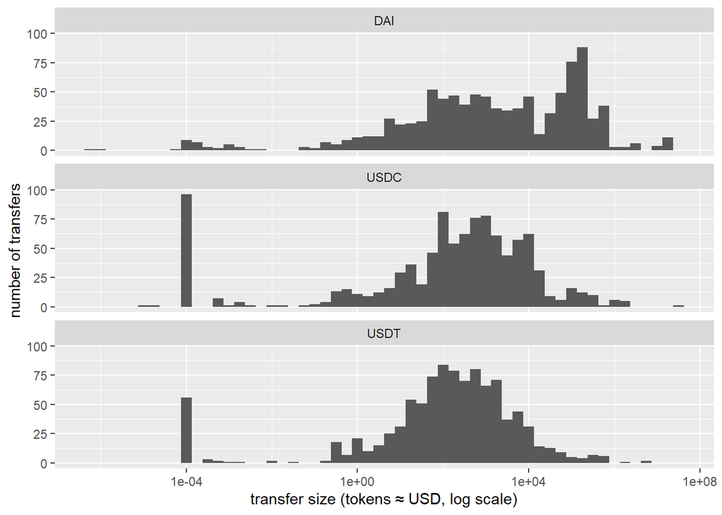

```r
ggplot(sizes) +
  geom_histogram(aes(x = amount), binwidth = 0.25) +
  scale_x_log10() +
  facet_wrap(~ token, ncol = 1) +
  labs(x = "transfer size (tokens ≈ USD, log scale)",
       y = "number of transfers")
```

Share of transfers (%) in each size class:

```r
sizes |>
  mutate(size_class = cut(amount, c(0, 100, 10000, 1000000, Inf),
                          labels = c("< 100", "100 to 10k", "10k to 1M", "1M or more"),
                          right = FALSE)) |>
  count(token, size_class) |>
  group_by(token) |>
  mutate(share = round(n / sum(n) * 100, 1)) |>
  select(-n) |>
  pivot_wider(names_from = token, values_from = share, values_fill = 0)
```

```
## # A tibble: 4 × 4
##   size_class   DAI  USDC  USDT
##   <fct>      <dbl> <dbl> <dbl>
## 1 < 100       27.1  36.4  41.5
## 2 100 to 10k  34.2  51.3  50.9
## 3 10k to 1M   36.3  11.5   7.3
## 4 1M or more   2.5   0.8   0.3
```

## 2. How much transfer volume does each stablecoin generate?

Transfers from or to the zero address are mints (new tokens created) and burns (tokens destroyed): we also report how much of the volume they make up.

```r
zero_address <- "0x0000000000000000000000000000000000000000"

volumes <- transfers |>
  mutate(mint_burn = from == zero_address | to == zero_address) |>
  group_by(token) |>
  summarise(transfers = n(),
            volume = sum(amount),
            mint_burn_share = sum(amount[mint_burn]) / volume * 100,
            start = as_datetime(min(time)),
            end = as_datetime(max(time)),
            hours = (max(time) - min(time)) / 3600) |>
  mutate(transfers_per_hour = transfers / hours,
         volume_per_hour = volume / hours) |>
  arrange(desc(volume_per_hour))

volumes
```

```
## # A tibble: 3 × 9
##   token transfers volume mint_burn_share start               end
##   <chr>     <int>  <dbl>           <dbl> <dttm>              <dttm>
## 1 USDC       1000 5.49e7            3.46 2026-11-03 13:51:47 2026-11-03 13:53:47
## 2 USDT       1000 2.03e7            0    2026-11-03 13:51:47 2026-11-03 13:53:47
## 3 DAI        1000 2.83e8           45.6  2026-11-03 12:25:59 2026-11-03 13:53:35
## # ℹ 3 more variables: hours <dbl>, transfers_per_hour <dbl>,
## #   volume_per_hour <dbl>
```

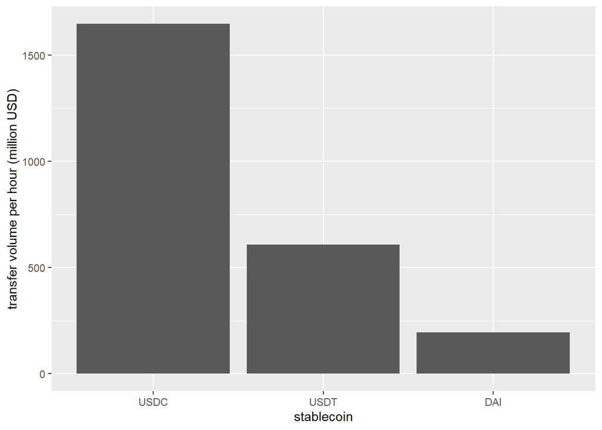

```r
ggplot(volumes) +
  geom_col(aes(x = reorder(token, -volume_per_hour), y = volume_per_hour / 1e6)) +
  labs(x = "stablecoin",
       y = "transfer volume per hour (million USD)")
```